## output: html_document

# This is an analysis of the Schmidt2017svm project

```r
#load("multidim_Tarabykin.rdata")
summary (as.factor(metadata$groupingvar))
```

```
##          Npr2 flox/flox Npr2 flox/flox;Wnt1 Cre
##                      13                      14
```

```r
numberofvariables = (length(names(behav_gp))-3)* nrow (Timewindows)
numberofvariables = trunc(numberofvariables/3)
```

The data is grouped by genotype. Data transformation: data (%age of time spent doing the behavior) transformed using the square root method..

We grouped the variables following the AOCF argument to get 17 behavior categories. We used the folowing time windows and got 17 x 6 = 102 variables :

```r
pander::pandoc.table(Timewindows)
```

| time_reference | windowstart | windowend |
| --- | --- | --- |
| Bin | 0 | 120 |
| Bintodark | -120 | 0 |
| Bintodark | 0 | 180 |
| Bintodark | 180 | 540 |
| Bintodark | 540 | 720 |
| Bintodark | 720 | 840 |

Note that the last window might be truncated if not all dataset is achieving 900 min after light on.

We then run a random forest to get the variables in order of importance to distinguish the groups.

We tried to tune the mtry parameter, but the function “tuneRF” gives different minima each time we run it, so we decided to keep the default value (sqrt(p), here p = 102 ).

```r
tuneRF(Multi_datainput_m%>% select (-groupingvar),Multi_datainput_m$groupingvar, ntreeTry=50, stepFactor=2, improve=0.05,
       trace=TRUE, plot=TRUE, doBest=FALSE)

tuneRF(Multi_datainput_m%>% select (-groupingvar),Multi_datainput_m$groupingvar, ntreeTry=50, stepFactor=2, improve=0.05,
       trace=TRUE, plot=TRUE, doBest=FALSE)
```

[output not shown]

We therefore used the random forest using the default mtry value and plot here the table of variables ordered by weight:

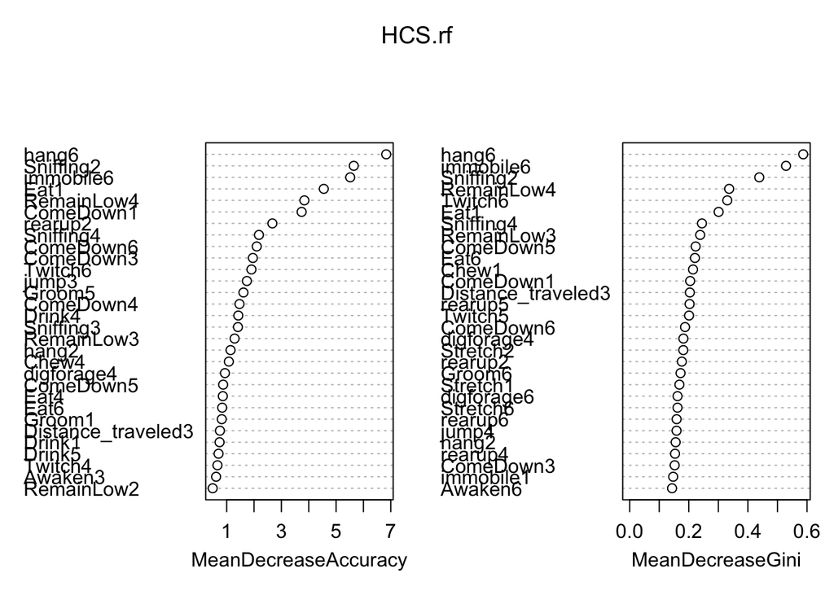

```r
HCS.rf <- randomForest(groupingvar ~ ., data=Multi_datainput_m, importance=TRUE,
                        proximity=TRUE, ntree =1500)

R =round(importance(HCS.rf, type=2), 2)
R2=data.frame(row.names (R),R)  %>% arrange(-MeanDecreaseGini)

#pander::pandoc.table(R2)
varImpPlot(HCS.rf)
```

let’s try to get only the 34 first variables and run the random forest again:

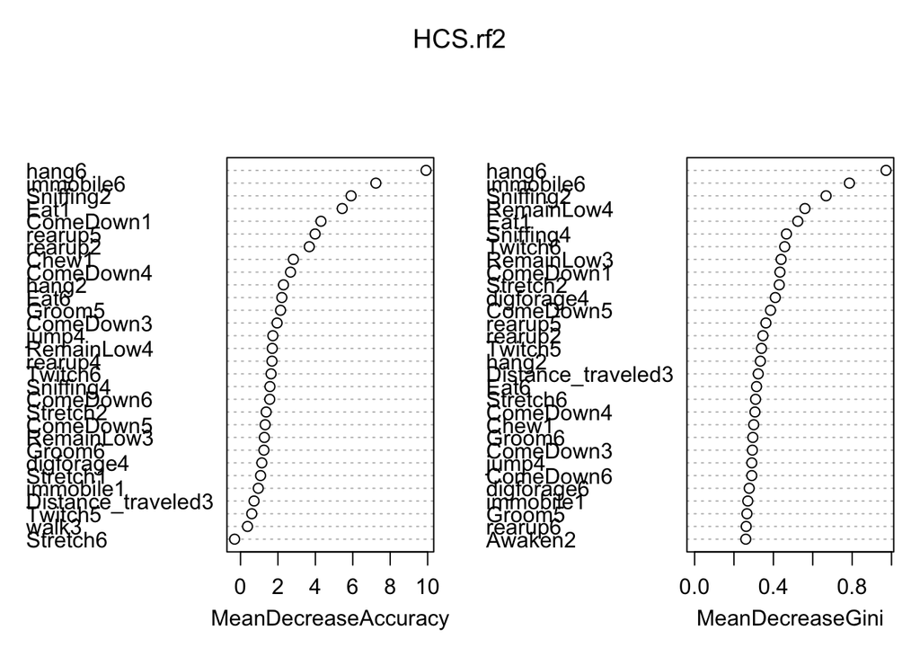

```r
Input =Multi_datainput_m [,names(Multi_datainput_m) %in% as.character(R2 [1:numberofvariables,1]) ]
Input$groupingvar =Multi_datainput_m$groupingvar

HCS.rf2 <- randomForest(groupingvar ~ ., data=Input, importance=TRUE,
                        proximity=TRUE, ntree =1500)
R =round(importance(HCS.rf2, type=2), 2)
R2=data.frame(row.names (R),R)  %>% arrange(-MeanDecreaseGini)

#pander::pandoc.table(R2)

varImpPlot(HCS.rf2)
```

Let’s take a teshold of of importance import_treshold and get all variables giving a MeanDecreaseGini over it (NB: THIS VARIABLE MIGHT NEED TO BE SET FOR EACH DATA), at least 6 data points:

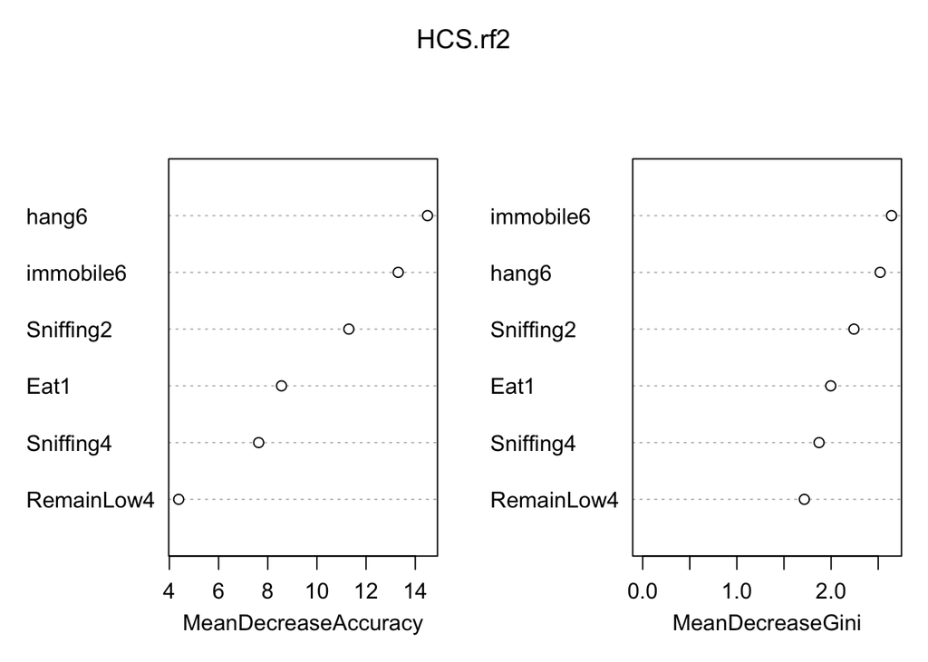

```r
 import_treshold =0.95

R3=data.frame(row.names (R),R)  %>%
  filter(MeanDecreaseGini > import_treshold)
numberofvariables =max (nrow (R3), 6)

Input =Multi_datainput_m [,names(Multi_datainput_m) %in% as.character(R2 [1:numberofvariables,1]) ]
Input$groupingvar =Multi_datainput_m$groupingvar

HCS.rf2 <- randomForest(groupingvar ~ ., data=Input, importance=TRUE,
                        proximity=TRUE, ntree =1500)
varImpPlot(HCS.rf2)
```

# Plotting

First, lets plot the 2 most discriminative variables following the random forest:

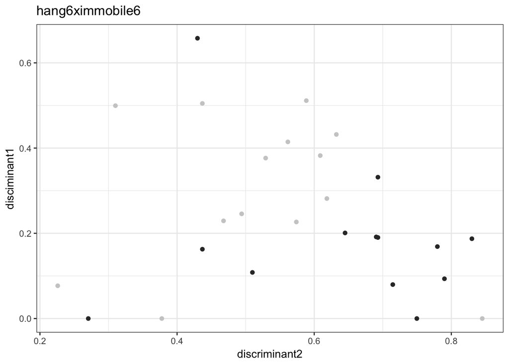

```r
 Plot = Multi_datainput_m [,names(Multi_datainput_m) %in% as.character(R2 [1:2,1]) ]
  Plot = cbind(Multi_datainput_m$groupingvar, Plot)
  Title_plot = paste0(names (Plot) [2],"x",names (Plot) [3])
  names (Plot) = c("groupingvar","disciminant1", "discriminant2")
  p=ggplot (Plot, aes (y= disciminant1, x=discriminant2, color= groupingvar))+
    geom_point()+
    labs(title = Title_plot)+
    #scale_x_log10() + scale_y_log10()+
    scale_colour_grey() + theme_bw()+
      theme(legend.position='none')
print(p)
```

Now is the time to plot the main components. For this, we will make an ICA on the reduced data and plot the first two components:

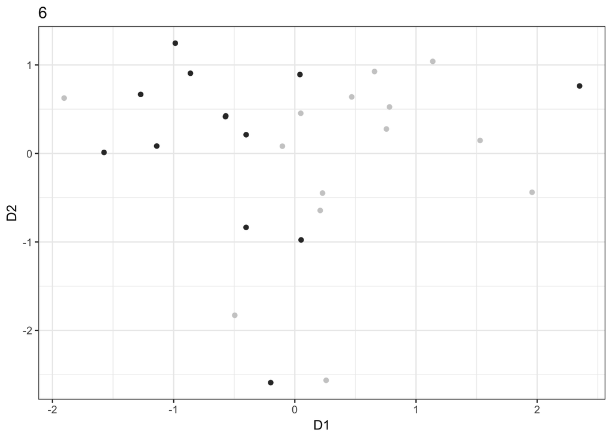

```r
 p=icafast(Input%>% select (-groupingvar),2,center=T,maxit=100)

R= cbind(p$Y, Input   %>% select (groupingvar))
    names(R) = c("D1", "D2",  "groupingvar")
    pls=R %>% ggplot (aes (x=D1, y=D2, color = groupingvar))+
      geom_point()+
      labs (title=numberofvariables)+
      scale_colour_grey() + theme_bw()+
      theme(legend.position='none')
print(pls)
```

# SVM

We perform a SVM on the total data or the reduced data and compare the results. For that with split the data in training and test sets, tune the svm for best parameters and then run the svm and gives the overall accuracy as the output. (the optimization of the parameters is computer intensive and may take time).

```r
if (nrow(trainset)< 20) {print("the sample size is not sufficient to produce a svm analysis, you need at least 15 animals per group")
  NOSTAT=TRUE
}else{
  #tuning: choose best kernel (error rate minimal), all data or only a subset (accuracy on trainset maximal, use all if identical), this takes time!
source ("../Rcode/Tuning_svm.r")
# run model on test data
  svm.pred <- predict(svm.model, testset %>% select(-groupingvar))

  SVMprediction_res =table(pred = svm.pred, true = testset$groupingvar)
  SVMprediction = as.data.frame(SVMprediction_res)
  Accuracyreal= temp$crand
  #Accuracy of grouping and plot
  temp =classAgreement (SVMprediction_res)
  Accuracy =paste0(ncol(Input)-1," variables: Accuracy of the prediction with ",bestk[[1]]," kernel (Corrected Rand index: 0 denotes chance level, maximum is 1):",Accuracyreal)

  print(Accuracy)
}
```

```
## [1] "the sample size is not sufficient to produce a svm analysis, you need at least 15 animals per group"
```

This will take very long, 1h for 80 permutations.

```r
Npermutation = 100

if (!NOSTAT) {
trainsetp=trainset
Acc_sampled= c()
b=Sys.time()
for (i in 1:Npermutation){

#permute trainset:

#taking all permutation is impossible when we get more than 5 animals per group.
trainsetp$groupingvar=sample (trainset$groupingvar)
#create svm model: we tune only in one kernel:
obj <- tune.svm(groupingvar~., data = trainsetp, gamma = 4^(-5:5), cost = 4^(-5:5),
                   tune.control(sampling = "cross"),kernel = bestk[[1]])

svm.model <- svm(groupingvar ~ ., data = trainsetp, cost = obj$best.parameters$cost, gamma = obj$best.parameters$gamma, kernel = bestk[[1]])

svm.pred <- predict(svm.model, testset %>% select(-groupingvar))
SVMprediction_res =table(pred = svm.pred, true = testset$groupingvar)
SVMprediction = as.data.frame(SVMprediction_res)

#Accuracy of grouping and plot
temp =classAgreement (SVMprediction_res)
Acc_sampled = c(Acc_sampled, temp$crand)
}

Sys.time()-b

hist(Acc_sampled, breaks=c(-10:10)/10)
abline(v = Accuracyreal, col="Red")

                                 # Exports `binconf`
k <- sum(abs(Acc_sampled) >= abs(Accuracyreal))   # Two-tailed test
zapsmall(binconf(k, length(Acc_sampled), method='exact')) # 95% CI by default
}
```